# Praca domowa 2

Kacper Mocarski

## Dane

Dane wykorzystane w Pracy domowej 2 są związane z kampaniami marketingu bezpośredniego portugalskiej instytucji bankowej. Kampanie marketingowe opierały się na rozmowach telefonicznych. Często wymagany był więcej niż jeden kontakt z tym samym klientem, aby uzyskać dostęp do tego, czy produkt (lokata bankowa) zostanie (lub nie) subskrybowany. Opis wszystkich kolumn znajduje się również w pliku `README.md`.

#### Dane klienta banku

| Zmienna | Opis |
| --- | --- |
| **age** | wiek |
| **job** : admin., unknown, unemployed, management, housemaid, entrepreneur, student, blue-collar, self-employed, retired, technician, services | administrator, nieznany, bezrobotny, kierownictwo, pokojówka, przedsiębiorca, student, pracownik fizyczny, samozatrudniony, emeryt, technik, usługi |
| **marital** : married, divorced, single; note: divorced means divorced or widowed) | żonaty/zamężna, rozwiedzion_, kawaler/panna; uwaga: rozwiedzion_ oznacza rozwiedzion_ lub owdowiał_ |
| **education** : unknown, secondary, primary, tertiary | nieznane, średnie, podstawowe, wyższe |
| **default** : yes, no | czy kredyt jest niespłacany : tak, nie |
| **balance** : average yearly balance, in euros | średnie roczne saldo w euro |
| **housing** : has housing loan? yes, no | czy posiada kredyt mieszkaniowy? tak, nie |
| **loan** : has personal loan? yes, no | ma pożyczkę osobistą? tak, nie |

#### Dane związane z ostatnim kontaktem w bieżącej kampanii

| Zmienna | Opis |
| --- | --- |
| **contact** : unknown, telephone, cellular | nieznany, telefon, komórkowy |
| **day** : last contact day of the month | dzień miesiąca ostatniego kontaktu |
| **month** : last contact month of year, jan, feb, mar, …, nov, dec | miesiąc ostatniego kontaktu w roku, styczeń, luty, marzec, …, listopad, grudzień |
| **duration** : last contact duration, in seconds | czas trwania ostatniego kontaktu w sekundach |

## Zadanie 1

Weźmy pod uwagę zawody (`job`) klientów banku. Który zawód zacząco wyróżnia się w posiadaniu kredytu mieszkaniowego lub pożyczki osobistej?

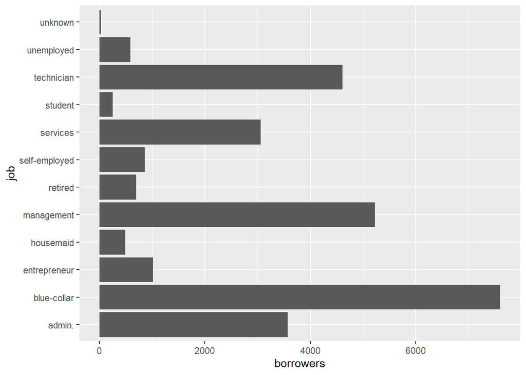

```r
# Tu umieść kod do wygenerowania odpowiedzi do zadania.
zad1 <- df %>%
  filter(housing=="yes" | loan=="yes") %>%
  group_by(job) %>%
  summarise(borrowers=n())

plot1 <- ggplot(zad1, aes(x = borrowers, y = job))+geom_col()
plot1
```

**Komentarz:** Grupą zawodową zacząco wyróżniającą się w posiadaniu kredytu mieszkaniowego lub pożyczki osobistej są pracownicy fizyczni (blue-collar).

## Zadanie 2

Wybierając klientów, którzy mają nieznany sposób kontaktu (`contact`). Jak rozkłada się ich wiek w podziale na status związku?

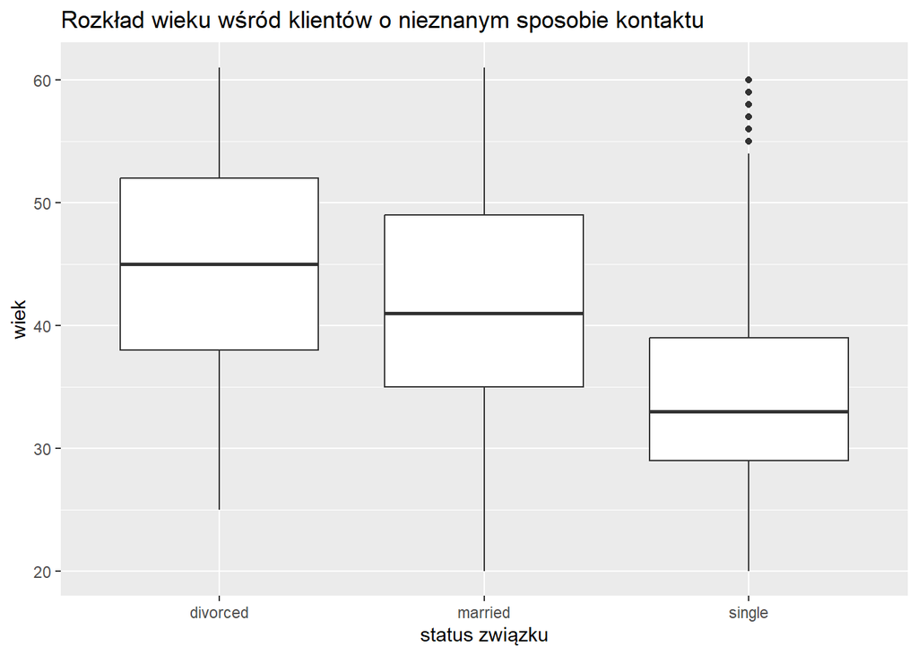

```r
# Tu umieść kod do wygenerowania odpowiedzi do zadania.
zad2 <- df %>%
  filter(contact=="unknown") %>%
  select(age,marital)

plot2 <-ggplot(zad2, aes(x = marital, y = age))+geom_boxplot()+ labs(title = "Rozkład wieku wśród klientów o nieznanym sposobie kontaktu",              y = "wiek",
       x = "status związku")
plot2
```

**Komentarz:** Wśród klientów, którzy mają nieznany sposób kontaktu wiek dla kolejnych grup rozkłada się następująco: -rozwiedzeni: większość osób jest w przedziale wiekowym 38-52, przy czym najwięcej ma ok. 45 lat. -żonaty/zamężna: większość osób jest w przedziale wiekowym 35-49, przy czym najwięcej ma ok. 41 lat -stanu wolnego: większość osób jest w przedziale wiekowym 29-39, przy czym najwięcej ma ok. 33 lata

## Zadanie 3

Jaka jest różnica pomiędzy średnim rocznym saldem w euro w zależności od wykształcenia i tego czy kredyt jest niespłacany?

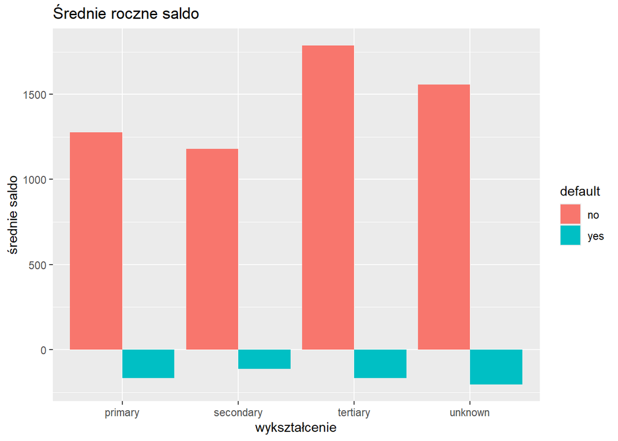

```r
# Tu umieść kod do wygenerowania odpowiedzi do zadania.
zad3 <- df %>%
  select(balance,education,default) %>%
  group_by(education,default) %>%
  summarise(balance=mean(balance))
plot3 <- ggplot(zad3, aes(x = education, y = balance, fill = default)) + geom_col(position = "dodge") + labs(title = "Średnie roczne saldo",              x = "wykształcenie",
       y = "średnie saldo")
plot3
```

**Komentarz:** We wszystkich grupach wykształcenia osoby spłacające kredyt mają średnio znacznie większe średnie saldo od tych, którzy mają zadłużenie, największe średnie saldo mają osoby bez zadłużeń z wyższym wykształceniem, natomiast we wszystkich grupach osoby posiadające zadłużenie mają ujemne średnie roczne saldo, najniższe jest dla osób o nieznanym wykształceniu.

## Zadanie 4

Czy dzień i miesiąc kontaktu z klientem ma wpływ na średni czas trwania rozmowy w stosunku do średniego czasu trwania rozmowy?

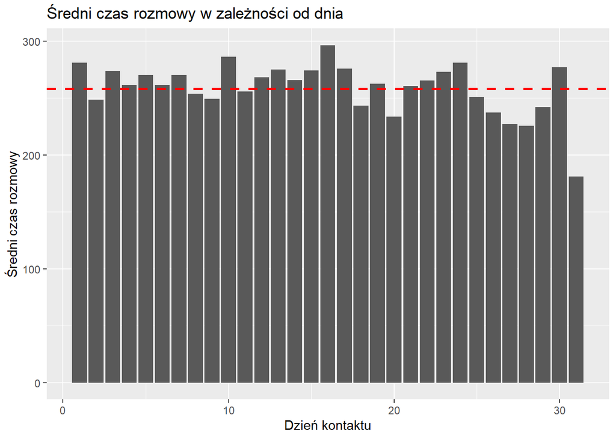

```r
# Tu umieść kod do wygenerowania odpowiedzi do zadania.
średnia <- mean(df$duration)
plot4.1 <- df %>%
  group_by(day) %>%
  summarise(sredni_czas_rozmowy=mean(duration)) %>%
  ggplot(aes(x=day, y=sredni_czas_rozmowy))+
  geom_col()+
  geom_hline(yintercept = średnia, color = "red", linetype = "dashed", linewidth = 1)+
  labs(title = "Średni czas rozmowy w zależności od dnia",
       x = "Dzień kontaktu",
       y = "Średni czas rozmowy")
plot4.2 <- df %>%
  group_by(month) %>%
  summarise(sredni_czas_rozmowy=mean(duration)) %>%
  ggplot(aes(x=month, y=sredni_czas_rozmowy))+
  geom_col()+
  geom_hline(yintercept = średnia, color = "red", linetype = "dashed", linewidth = 1)+
  labs(title = "Średni czas rozmowy w zależności od dnia",
       x = "Miesiąc kontaktu",
       y = "Średni czas rozmowy")
plot4.1
```

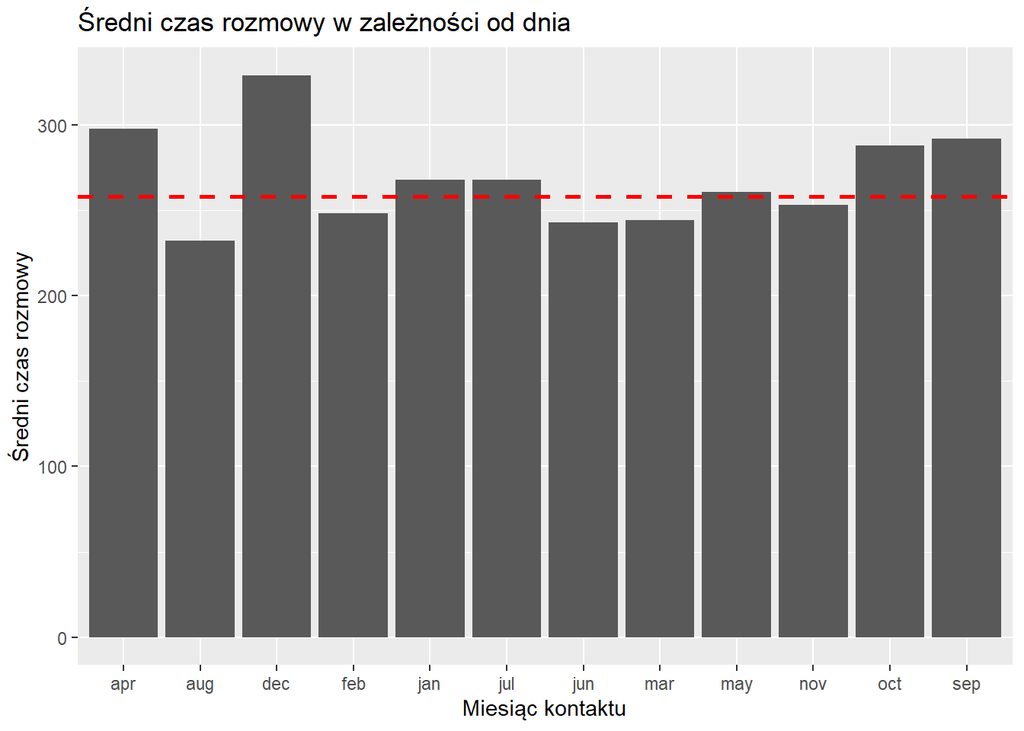

```r
plot4.2
```

**Komentarz:** W grudniu możemy zaobserwować wydłużenie się średniego czasu rozmowy o około minutę, w pozostałych miesiącach średnia długość rozmowy nieznacznie odbiega od ogólnej średniej. Natomiast jeśli chodzi o dzień kontaktu to największym odstępstwem charakteryzuje się 31, wtedy rozmowy są krótsze średnio o ponad minutę.

## Zadanie 5

Czy jest zależnośc pomiędzy wiekiem klientów a ich średnim rocznym saldzie w euro w podziale na stopień wykształcenia?

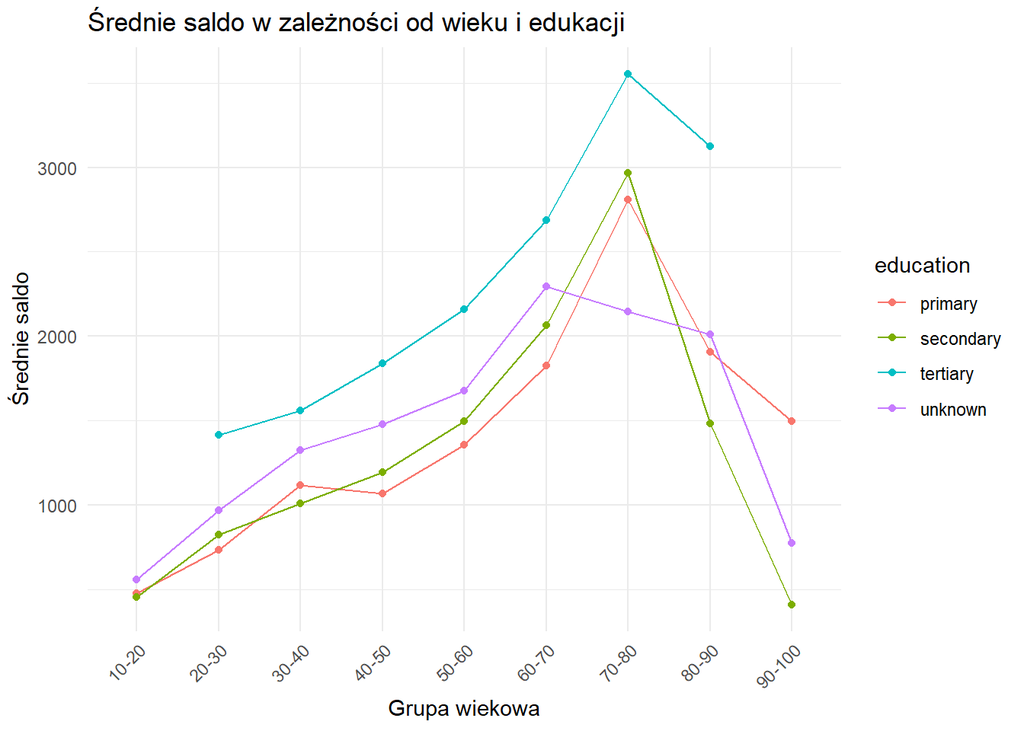

```r
test <- df %>% select(age,balance,education) %>%filter(balance>60000) # widzimy, że 8 na 45221 obserwacji spełnia warunek, że balance>60000 zatem możemy je traktować jako odstające wartości skrajne, które w znaczącym stopniu wpływają na wykres średniej dlatego pozwolę sobie je wyrzucić z próbki
zad5 <- df %>%
  select(education,balance,age) %>%
  mutate(grupa_wiekowa=cut(age, breaks = seq(0, 100, by = 10),right = FALSE,labels = paste(seq (0, 90, 10), seq(10, 100, 10), sep = "-")))%>%
  filter(balance<60000) %>%
  group_by(education,grupa_wiekowa) %>%
  summarise(średnie=mean(balance))

plot5 <- ggplot(zad5, aes(x = grupa_wiekowa, y = średnie, colour = education,group = education)) +
  geom_line() +
  geom_point() +
  labs(x = "Grupa wiekowa", y = "Średnie saldo", title = "Średnie saldo w zależności od wieku i edukacji") +
  theme_minimal() +
  theme(axis.text.x = element_text(angle = 45, hjust = 1))

plot5
```

## Zadanie 6

Rozważmy osoby, które są bezrobotne albo ich zawód jest nieznany. Czy procent osób, które są bezrobotne i nie spłacają kredytu jest większy od procenta osób o nieznanym zawodzie i nie spłacanym kredycie? Jaki typ kredytu jest (przez te osoby) najczęściej niespłacany?

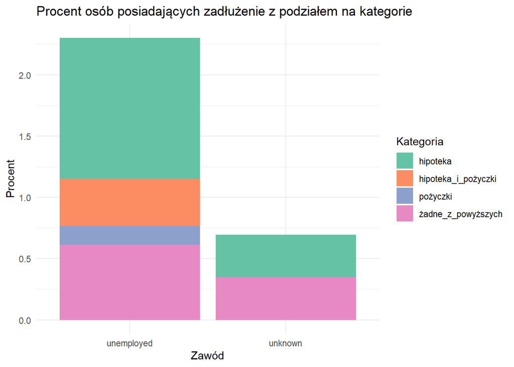

```r
# Tu umieść kod do wygenerowania odpowiedzi do zadania.
zad6 <-  df %>%
  filter(job=="unknown"|job=="unemployed") %>%
  select(job,default,loan,housing) %>%
  group_by(job) %>%
  summarise(hipoteka=sum(default=="yes"&housing=="yes"&loan=="no")/n()*100,pożyczki=sum(default=="yes"& housing=="no"& loan=="yes")/n()*100,hipoteka_i_pożyczki=sum(default=="yes"& housing=="yes" & loan=="yes")/n()*100,żadne_z_powyższych=sum(default=="yes"&housing=="no"&loan=="no")/n()*100) %>%
   pivot_longer(cols = c(hipoteka, pożyczki, hipoteka_i_pożyczki, żadne_z_powyższych), names_to = "Kategoria", values_to = "Procent")
plot6 <- ggplot(zad6, aes(x = job, y = Procent, fill = Kategoria)) +
  geom_bar(stat = "identity") +
  labs(
    title = "Procent osób posiadających zadłużenie z podziałem na kategorie",
    x = "Zawód",
    y = "Procent",
    fill = "Kategoria"
  ) +
  theme_minimal() +
  scale_fill_brewer(palette = "Set2")
plot6
```

**Komentarz:**

Procent osób, które są bezrobotne i nie spłacają kredytu jest około 3-krotnie większy od procenta osób o nieznanym zawodzie i nie spłacanym kredycie.W grupie bezrobotnych najczęściej niespłacany jest kredyt hipoteczny,dla osób o nieznanym zawodzie analiza tych danych jest bezsensowna, ponieważ są to 2 osoby (jedna nie spłaca hipoteki, druga natomiast ma zadłużenie nieznanego pochodzenia).